# `knitr_container` Examples

(spPlot v0.1.1)

Vilmantas Gegzna

2016-05-28

# 1 Functions for class `knitr_container`

Load packages.

```r
library(spHelper)
library(spPlot)
```

Create necessary objects.

```r
plotly_obj <- plot_ly(economics, x = date, y = uempmed, type = "scatter",
             showlegend = FALSE)

ggplot_obj <- qplot(mpg, wt, data = mtcars, colour = cyl)
```

Create `knitr_container`.

```r
obj <- knitr_container()
class(obj)
```

```
#> [1] "knitr_container" "list"
```

```r
obj
```

```
#> *** Empty container ***
```

Attach objects to the end of the container.

```r
obj <- add_as_section(obj, "Plots")

obj <- add_as_section(obj, "Add `plotly`", level = 2)
obj <- add_as_plotly_widget(obj, plotly_obj)

obj <- add_as_section(obj, "Add `ggplot` as `plotly`", level = 2)
obj <- add_as_plotly_widget(obj, ggplot_obj)

obj <- add_as_section(obj, "Add `ggplot`", level = 2)
obj <- add_as_is(obj, ggplot_obj)

obj <- add_as_section(obj, "Attention: Not Plotted", level = 1)
obj <- add_as_is(obj, plotly_obj)
obj <- add_as_text(obj, paste("As you noticed, the last",
      "`plotly` object was not plotted as it was added with ",
      "`add_as_is()` and not with `add_as_plotly_widget()`"))


obj <- add_as_section(obj, "Pander and text", level = 1)

obj <- add_as_section(obj, "As pander", level = 2)
obj <- add_as_pander(obj, summary(mtcars))

obj <- add_as_section(obj, "As text", level = 2)
obj <- add_as_text(obj, summary(mtcars))

obj <- add_as_section(obj, "As is", level = 2)
obj <- add_as_is(obj, summary(mtcars))
```

# 2 Explore the container

Note, that functions `summary(obj)` and `print(obj)` do the same action: print summary of the object

```r
print(obj)
```

```
#> ==========================================================================================
#> *** knitr container ***
#>
#> Contains 17 object(s):
#>
#>    Added.as      Text                      Size
#> 1  Section       # Plots                   0.3 Kb
#> 2  Section       ## Add `plotly`           0.3 Kb
#> 3  Plotly object                           17.1 Kb
#> 4  Section       ## Add `ggplot` as `pl... 0.3 Kb
#> 5  Plotly object                           37.6 Kb
#> 6  Section       ## Add `ggplot`           0.3 Kb
#> 7  As is                                   11.1 Kb
#> 8  Section       # Attention: Not Plott... 0.3 Kb
#> 9  As is                                   22.2 Kb
```

[output cut: 27 more lines]

```r
is.knitr_container(obj)
```

```
#> [1] TRUE
```

```r
is.knitr_container(ggplot_obj)
```

```
#> [1] FALSE
```

```r
as.knitr_container(ggplot_obj)
```

```
#> ==========================================================================================
#> *** knitr container ***
#>
#> Contains 1 object(s):
#>
#>   Added.as Text Size    Classes
#> 1 As is         11.1 Kb gg, ggplot
#> ==========================================================================================
```

```r
class(obj)
```

```
#> [1] "knitr_container" "list"
```

Merge several containers.

```r
Join(obj, obj)   %>% length()
```

```
#> [1] 34
```

Convert (as is) to `knitr_container` and merge.

```r
Join(obj, ggplot_obj)   %>% length()
```

```
#> [1] 18
```

As function uses method “as is” to convert to `knitr_container`, `plotly` objects might not be printed from the container in some situations (e.g. from inside `for` loops using `knitr`).

```r
Join(ggplot_obj, plotly_obj)
```

```
#> ==========================================================================================
#> *** knitr container ***
#>
#> Contains 2 object(s):
#>
#>   Added.as Text Size    Classes
#> 1 As is         11.1 Kb gg, ggplot
#> 2 As is         22.2 Kb plotly_hash, tbl_df, tbl, data.frame
#> ==========================================================================================
```

In these situations it is better to apply function `add_as_plotly_widget` first.

# 3 Print objects from the container (`print_objects`)

For this purpose a special function `print_objects` was created. As we use `knitr` and `R MArkdown` we recommend to use separate R code chunk to apply the function. It is IMPORTANT to make sure that R chunk, in which `print_objects()` is called, has option `results` set to `as is` (`{r, results = 'asis'}`). Otherwise incorrect results are expected.

The following text, section headings, figures etc. (except section “Session information”) are printed from the container using the following syntax:

```r
print_objects(obj)
```

# 4 Plots

## 4.1 Add `plotly`

[interactive chart not shown]

## 4.2 Add `ggplot` as `plotly`

[interactive chart not shown]

## 4.3 Add `ggplot`

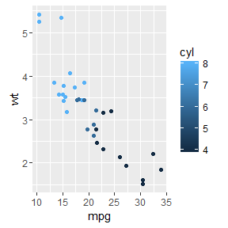

# 5 Attention: Not Plotted

As you noticed, the last `plotly` object was not plotted as it was added with `add_as_is()` and not with `add_as_plotly_widget()`

# 6 Pander and text

## 6.1 As pander

Table continues below

| mpg | cyl | disp | hp | drat |
| --- | --- | --- | --- | --- |
| Min. :10.40 | Min. :4.000 | Min. : 71.1 | Min. : 52.0 | Min. :2.760 |
| 1st Qu.:15.43 | 1st Qu.:4.000 | 1st Qu.:120.8 | 1st Qu.: 96.5 | 1st Qu.:3.080 |
| Median :19.20 | Median :6.000 | Median :196.3 | Median :123.0 | Median :3.695 |
| Mean :20.09 | Mean :6.188 | Mean :230.7 | Mean :146.7 | Mean :3.597 |
| 3rd Qu.:22.80 | 3rd Qu.:8.000 | 3rd Qu.:326.0 | 3rd Qu.:180.0 | 3rd Qu.:3.920 |
| Max. :33.90 | Max. :8.000 | Max. :472.0 | Max. :335.0 | Max. :4.930 |

Table continues below

| wt | qsec | vs | am | gear |
| --- | --- | --- | --- | --- |
| Min. :1.513 | Min. :14.50 | Min. :0.0000 | Min. :0.0000 | Min. :3.000 |
| 1st Qu.:2.581 | 1st Qu.:16.89 | 1st Qu.:0.0000 | 1st Qu.:0.0000 | 1st Qu.:3.000 |
| Median :3.325 | Median :17.71 | Median :0.0000 | Median :0.0000 | Median :4.000 |
| Mean :3.217 | Mean :17.85 | Mean :0.4375 | Mean :0.4062 | Mean :3.688 |
| 3rd Qu.:3.610 | 3rd Qu.:18.90 | 3rd Qu.:1.0000 | 3rd Qu.:1.0000 | 3rd Qu.:4.000 |
| Max. :5.424 | Max. :22.90 | Max. :1.0000 | Max. :1.0000 | Max. :5.000 |

| carb |
| --- |
| Min. :1.000 |
| 1st Qu.:2.000 |
| Median :2.000 |
| Mean :2.812 |
| 3rd Qu.:4.000 |
| Max. :8.000 |

## 6.2 As text

Min. :10.40 1st Qu.:15.43 Median :19.20 Mean :20.09 3rd Qu.:22.80 Max. :33.90 Min. :4.000 1st Qu.:4.000 Median :6.000 Mean :6.188 3rd Qu.:8.000 Max. :8.000 Min. : 71.1 1st Qu.:120.8 Median :196.3 Mean :230.7 3rd Qu.:326.0 Max. :472.0 Min. : 52.0 1st Qu.: 96.5 Median :123.0 Mean :146.7 3rd Qu.:180.0 Max. :335.0 Min. :2.760 1st Qu.:3.080 Median :3.695 Mean :3.597 3rd Qu.:3.920 Max. :4.930 Min. :1.513 1st Qu.:2.581 Median :3.325 Mean :3.217 3rd Qu.:3.610 Max. :5.424 Min. :14.50 1st Qu.:16.89 Median :17.71 Mean :17.85 3rd Qu.:18.90 Max. :22.90 Min. :0.0000 1st Qu.:0.0000 Median :0.0000 Mean :0.4375 3rd Qu.:1.0000 Max. :1.0000 Min. :0.0000 1st Qu.:0.0000 Median :0.0000 Mean :0.4062 3rd Qu.:1.0000 Max. :1.0000 Min. :3.000 1st Qu.:3.000 Median :4.000 Mean :3.688 3rd Qu.:4.000 Max. :5.000 Min. :1.000 1st Qu.:2.000 Median :2.000 Mean :2.812 3rd Qu.:4.000 Max. :8.000

## 6.3 As is

```
  mpg             cyl             disp             hp
```

Min. :10.40 Min. :4.000 Min. : 71.1 Min. : 52.0  
1st Qu.:15.43 1st Qu.:4.000 1st Qu.:120.8 1st Qu.: 96.5  
Median :19.20 Median :6.000 Median :196.3 Median :123.0  
Mean :20.09 Mean :6.188 Mean :230.7 Mean :146.7  
3rd Qu.:22.80 3rd Qu.:8.000 3rd Qu.:326.0 3rd Qu.:180.0  
Max. :33.90 Max. :8.000 Max. :472.0 Max. :335.0  
drat wt qsec vs  
Min. :2.760 Min. :1.513 Min. :14.50 Min. :0.0000  
1st Qu.:3.080 1st Qu.:2.581 1st Qu.:16.89 1st Qu.:0.0000  
Median :3.695 Median :3.325 Median :17.71 Median :0.0000  
Mean :3.597 Mean :3.217 Mean :17.85 Mean :0.4375  
3rd Qu.:3.920 3rd Qu.:3.610 3rd Qu.:18.90 3rd Qu.:1.0000  
Max. :4.930 Max. :5.424 Max. :22.90 Max. :1.0000  
am gear carb  
Min. :0.0000 Min. :3.000 Min. :1.000  
1st Qu.:0.0000 1st Qu.:3.000 1st Qu.:2.000  
Median :0.0000 Median :4.000 Median :2.000  
Mean :0.4062 Mean :3.688 Mean :2.812  
3rd Qu.:1.0000 3rd Qu.:4.000 3rd Qu.:4.000  
Max. :1.0000 Max. :5.000 Max. :8.000

[session information not shown]